# Predicting Student Performance from Survey Data

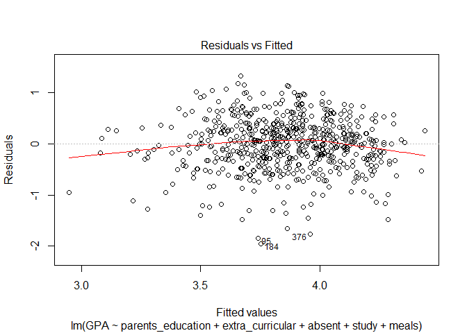

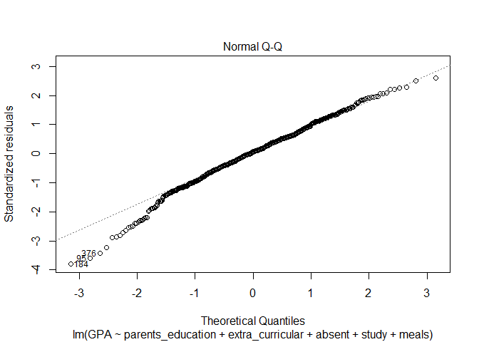

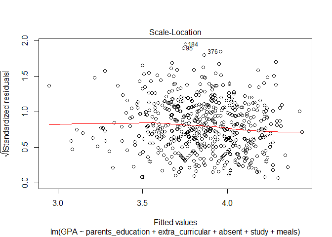

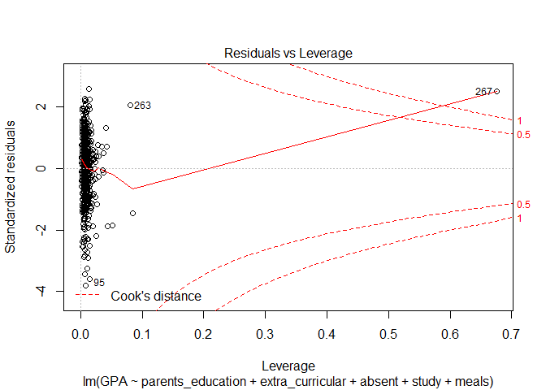

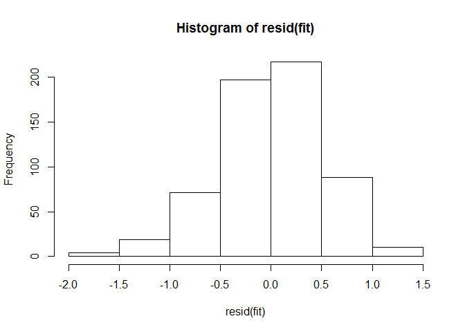

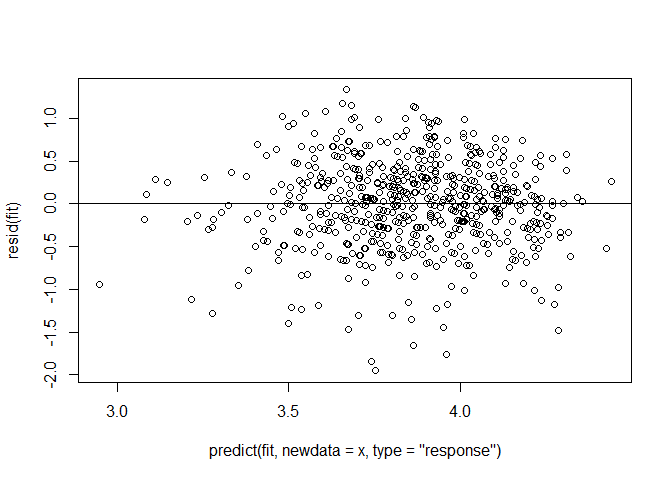

```r
assess_linear_model(fit)
```

The Normal Q-Q plot has a notable tail at the theoretical quantity -2 and the R^2-adjusted of 0.1747 leads us to abandon this model.

Let us now move to Logit regression.

# Logit

I am defining better then average GPA as one standard deviation above the mean.

```r
better_then_average_GPA <- mean(x$GPA) + abs(sd(x$GPA))
x <- x %>% mutate(good_GPA = ifelse(GPA >= better_then_average_GPA, 1, 0))

model_eval <- function(mylogit) {

  tmp <- data.frame(mylogit$coefficients, exp(coef(mylogit)))
  tmp

  # The chi-square of null.deviance - deviance with df.null - df.residual degrees of
  # freedom and an associated p-value of less than 0.001 tells us that our over all
  # model as a whole fits significantly better than an empty model.
  #
  tmp <- with(mylogit, pchisq(null.deviance - deviance, df.null - df.residual, lower.tail = FALSE))
  cat("The chi-square of the model is:", tmp, "is < p-value 0.001:", (tmp < 0.001), "\n")

  # This is sometimes called a likelihood ratio test (the deviance residual is -2*log likelihood).
  cat("The likelihood ratio test:", logLik(mylogit), "\n")

  cat("Odds Ratios and 95% Confidence Intervals \n")
  exp(cbind(OR = coef(mylogit), confint(mylogit)))

  anova(mylogit, test="Chisq")

}


# starting point.
mylogit <- x %>% glm(good_GPA ~ mother + age + father + band + club + sport + romance, data = ., family = "binomial")
summary(mylogit)
```

```
##
## Call:
## glm(formula = good_GPA ~ mother + age + father + band + club +
##     sport + romance, family = "binomial", data = .)
##
## Deviance Residuals:
##     Min       1Q   Median       3Q      Max
## -1.2113  -0.6108  -0.4395  -0.1908   2.8754
##
## Coefficients:
##              Estimate Std. Error z value Pr(>|z|)
## (Intercept) -13.85794    2.33231  -5.942 2.82e-09 ***
## mother       -0.02809    0.18238  -0.154 0.877601
## age           0.52398    0.11962   4.381 1.18e-05 ***
## father        0.37914    0.17608   2.153 0.031304 *
## band          0.51432    0.25835   1.991 0.046504 *
## club          2.17981    0.60322   3.614 0.000302 ***
## sport        -0.21814    0.25397  -0.859 0.390379
## romance      -0.32548    0.29904  -1.088 0.276417
## ---
## Signif. codes:  0 '***' 0.001 '**' 0.01 '*' 0.05 '.' 0.1 ' ' 1
##
## (Dispersion parameter for binomial family taken to be 1)
##
##     Null deviance: 491.40  on 605  degrees of freedom
## Residual deviance: 432.65  on 598  degrees of freedom
## AIC: 448.65
##
## Number of Fisher Scoring iterations: 6
```

```r
model_eval(mylogit)
```

```
## The chi-square of the model is: 2.68603e-10 is < p-value 0.001: TRUE
## The likelihood ratio test: -216.3254
## Odds Ratios and 95% Confidence Intervals
```

```
## Analysis of Deviance Table
##
## Model: binomial, link: logit
##
## Response: good_GPA
##
## Terms added sequentially (first to last)
##
##
##         Df Deviance Resid. Df Resid. Dev  Pr(>Chi)
## NULL                      605     491.40
## mother   1   1.1271       604     490.27   0.28838
## age      1  18.5859       603     471.68 1.624e-05 ***
## father   1   7.2502       602     464.43   0.00709 **
## band     1   6.4095       601     458.02   0.01135 *
## club     1  23.3787       600     434.64 1.330e-06 ***
## sport    1   0.7642       599     433.88   0.38203
## romance  1   1.2299       598     432.65   0.26742
## ---
## Signif. codes:  0 '***' 0.001 '**' 0.01 '*' 0.05 '.' 0.1 ' ' 1
```

```r
# Good AIC.  This was the largest number of variables I could get and still have low p-values.
mylogit <- x %>% glm(good_GPA ~ age + father + band + club, data = ., family = binomial("logit"))
summary(mylogit)
```

```
##
## Call:
## glm(formula = good_GPA ~ age + father + band + club, family = binomial("logit"),
##     data = .)
##
## Deviance Residuals:
##     Min       1Q   Median       3Q      Max
## -1.1175  -0.6053  -0.4472  -0.2015   2.7792
##
## Coefficients:
##             Estimate Std. Error z value Pr(>|z|)
## (Intercept) -14.0595     2.2409  -6.274 3.51e-10 ***
## age           0.5159     0.1185   4.354 1.33e-05 ***
## father        0.3837     0.1664   2.306 0.021103 *
## band          0.5620     0.2526   2.224 0.026119 *
## club          2.1502     0.6011   3.577 0.000347 ***
## ---
## Signif. codes:  0 '***' 0.001 '**' 0.01 '*' 0.05 '.' 0.1 ' ' 1
##
## (Dispersion parameter for binomial family taken to be 1)
##
##     Null deviance: 491.40  on 605  degrees of freedom
## Residual deviance: 434.65  on 601  degrees of freedom
## AIC: 444.65
##
## Number of Fisher Scoring iterations: 6
```

```r
model_eval(mylogit)
```

```
## The chi-square of the model is: 1.396392e-11 is < p-value 0.001: TRUE
## The likelihood ratio test: -217.3235
## Odds Ratios and 95% Confidence Intervals
```

```
## Analysis of Deviance Table
##
## Model: binomial, link: logit
##
## Response: good_GPA
##
## Terms added sequentially (first to last)
##
##
##        Df Deviance Resid. Df Resid. Dev  Pr(>Chi)
## NULL                     605     491.40
## age     1  17.9310       604     473.47 2.291e-05 ***
## father  1   8.9568       603     464.51  0.002764 **
## band    1   6.3745       602     458.13  0.011577 *
## club    1  23.4872       601     434.65 1.258e-06 ***
## ---
## Signif. codes:  0 '***' 0.001 '**' 0.01 '*' 0.05 '.' 0.1 ' ' 1
```

Each of the predictors has a p-value less then 0.05 thus we can reject the null hypotheses for each. The chi-square of the model is less then 0.001 so the model as a whole does have an effect of explaining the data as we reject the null hypotheses. Looking at the log odds of the coefficients we see that age, father’s education level, and band seem to all have log odds less then 2. This model has a high number of terms and still has low p-values for the predictors.

```r
mylogit <- x %>% glm(good_GPA ~ club + father + study, data = ., family = binomial("logit"))
summary(mylogit)
```

```
##
## Call:
## glm(formula = good_GPA ~ club + father + study, family = binomial("logit"),
##     data = .)
##
## Deviance Residuals:
##     Min       1Q   Median       3Q      Max
## -0.8390  -0.6271  -0.4970  -0.1983   2.8069
##
## Coefficients:
##             Estimate Std. Error z value Pr(>|z|)
## (Intercept) -5.58841    0.92369  -6.050 1.45e-09 ***
## club         2.08661    0.59938   3.481 0.000499 ***
## father       0.30659    0.16374   1.872 0.061140 .
## study        0.22114    0.08989   2.460 0.013893 *
## ---
## Signif. codes:  0 '***' 0.001 '**' 0.01 '*' 0.05 '.' 0.1 ' ' 1
##
## (Dispersion parameter for binomial family taken to be 1)
##
##     Null deviance: 491.40  on 605  degrees of freedom
## Residual deviance: 451.79  on 602  degrees of freedom
## AIC: 459.79
##
## Number of Fisher Scoring iterations: 6
```

```r
model_eval(mylogit)
```

```
## The chi-square of the model is: 1.293663e-08 is < p-value 0.001: TRUE
## The likelihood ratio test: -225.8969
## Odds Ratios and 95% Confidence Intervals
```

```
## Analysis of Deviance Table
##
## Model: binomial, link: logit
##
## Response: good_GPA
##
## Terms added sequentially (first to last)
##
##
##        Df Deviance Resid. Df Resid. Dev  Pr(>Chi)
## NULL                     605     491.40
## club    1  28.4741       604     462.92 9.496e-08 ***
## father  1   5.0456       603     457.88   0.02469 *
## study   1   6.0827       602     451.79   0.01365 *
## ---
## Signif. codes:  0 '***' 0.001 '**' 0.01 '*' 0.05 '.' 0.1 ' ' 1
```

```r
mylogit <- x %>% glm(good_GPA ~ parents_education + extra_curricular, data = ., family = binomial("logit"))
summary(mylogit)
```

```
##
## Call:
## glm(formula = good_GPA ~ parents_education + extra_curricular,
##     family = binomial("logit"), data = .)
##
## Deviance Residuals:
##     Min       1Q   Median       3Q      Max
## -0.7891  -0.5966  -0.5408  -0.4026   2.3437
##
## Coefficients:
##                   Estimate Std. Error z value Pr(>|z|)
## (Intercept)       -4.34811    0.91176  -4.769 1.85e-06 ***
## parents_education  0.20788    0.09973   2.084  0.03712 *
## extra_curricular   0.42071    0.15896   2.647  0.00813 **
## ---
## Signif. codes:  0 '***' 0.001 '**' 0.01 '*' 0.05 '.' 0.1 ' ' 1
##
## (Dispersion parameter for binomial family taken to be 1)
##
##     Null deviance: 491.40  on 605  degrees of freedom
## Residual deviance: 478.35  on 603  degrees of freedom
## AIC: 484.35
##
## Number of Fisher Scoring iterations: 5
```

```r
model_eval(mylogit)
```

```
## The chi-square of the model is: 0.001468482 is < p-value 0.001: FALSE
## The likelihood ratio test: -239.1746
## Odds Ratios and 95% Confidence Intervals
```

```
## Analysis of Deviance Table
##
## Model: binomial, link: logit
##
## Response: good_GPA
##
## Terms added sequentially (first to last)
##
##
##                   Df Deviance Resid. Df Resid. Dev Pr(>Chi)
## NULL                                605     491.40
## parents_education  1   5.7353       604     485.66 0.016627 *
## extra_curricular   1   7.3117       603     478.35 0.006851 **
## ---
## Signif. codes:  0 '***' 0.001 '**' 0.01 '*' 0.05 '.' 0.1 ' ' 1
```

The chi-square of the model is: 0.001468482 is > p-value 0.001 No further consideration of this models is needed since we fail to reject the null hypotheses.

```r
##Best model!
mylogit <- x %>% glm(good_GPA ~ club + study + parents + age + band, data = ., family = binomial("logit"))

summary(mylogit)
```

```
##
## Call:
## glm(formula = good_GPA ~ club + study + parents + age + band,
##     family = binomial("logit"), data = .)
##
## Deviance Residuals:
##     Min       1Q   Median       3Q      Max
## -1.3415  -0.6174  -0.4161  -0.1789   2.8782
##
## Coefficients:
##              Estimate Std. Error z value Pr(>|z|)
## (Intercept) -14.48236    2.22095  -6.521 6.99e-11 ***
## club          2.01267    0.60332   3.336  0.00085 ***
## study         0.27639    0.09293   2.974  0.00294 **
## parents       0.98997    0.42140   2.349  0.01881 *
## age           0.55405    0.12227   4.531 5.86e-06 ***
## band          0.50271    0.25588   1.965  0.04946 *
## ---
## Signif. codes:  0 '***' 0.001 '**' 0.01 '*' 0.05 '.' 0.1 ' ' 1
##
## (Dispersion parameter for binomial family taken to be 1)
##
##     Null deviance: 491.40  on 605  degrees of freedom
## Residual deviance: 424.33  on 600  degrees of freedom
## AIC: 436.33
##
## Number of Fisher Scoring iterations: 6
```

```r
model_eval(mylogit)
```

```
## The chi-square of the model is: 4.174636e-13 is < p-value 0.001: TRUE
## The likelihood ratio test: -212.1651
## Odds Ratios and 95% Confidence Intervals
```

```
## Analysis of Deviance Table
##
## Model: binomial, link: logit
##
## Response: good_GPA
##
## Terms added sequentially (first to last)
##
##
##         Df Deviance Resid. Df Resid. Dev  Pr(>Chi)
## NULL                      605     491.40
## club     1  28.4741       604     462.92 9.496e-08 ***
## study    1   7.2664       603     455.66  0.007026 **
## parents  1   6.7673       602     448.89  0.009285 **
## age      1  20.7396       601     428.15 5.262e-06 ***
## band     1   3.8188       600     424.33  0.050680 .
## ---
## Signif. codes:  0 '***' 0.001 '**' 0.01 '*' 0.05 '.' 0.1 ' ' 1
```

```r
# let's evaluate the model further


# changing variables to not have zero
x <- x %>% mutate(club_nz = ifelse(club == "0", 1, 2))
x <- x %>% mutate(band_nz = ifelse(band == "0", 1, 2))
x <- x %>% mutate(parents_nz = ifelse(parents == "0", 1, 2))

x <- x %>% mutate(study_nz = (study + 1))


#boxTidwell(good_GPA ~ club_nz + study_nz + parents_nz + age + band_nz, data=x, max.iter = 7)

boxTidwell(good_GPA ~ study_nz + age, ~ club_nz + parents_nz + band_nz, data=x, max.iter = 7)
```

```
##          Score Statistic   p-value MLE of lambda
## study_nz      -0.4109518 0.6811079 -6024.8036131
## age           -0.0280193 0.9776467     0.8635642
##
## iterations =  8
```

```r
rm(x,fit)
```

Each of the predictors has a p-value less then 0.05 thus we can reject the null hypotheses for each. The chi-square of the model is less then 0.001 so the model as a whole does have an effect of explaining the data as we reject the null hypotheses. Looking at the log odds of the coefficients we see that club and parents have the two highest log odds. Lets investigate this model further.

# Assumptions:

Linearity: The predictors club, parents, and band are binary thus linearity is automatic. Study and age are categorical and thus we will look at the Box Tidwell for study and age excluding the other binary variables. Since p-value > 0.05 for both age and study, we fail to reject the null hypotheses. This suggests that we meet the condition of linearity.

Randomness: AP High School Statistics students administered the survey. They made an attempt to reach all the students in the school, but did not get the full population. I’d consider it a very large random sample.

Independence: Each student’s GPA should be relatively independent. Typically the grades are not directly curved, just individual tests. Overall independence should not be an issue.

H0: β1 = 0 Ha: β1 ≠ 0 The odds ratio is Exp(B_club) = Exp(2.013) = 7.483. If a student is in a club, the odds of their GPA being above average increase by a factor of 7.483. Since p-value < 0.001, we reject the null hypothesis, suggesting there is a significant log-linear relationship between whether a student is in a club and the odds of their GPA being above average.

We are 95% confident that the true odds ratio is between 2.689 and 31.142. Since the 95% confidence interval of the odds ratio does not contain the value 1.0, the association is statistically significant at alpha = 0.05.

H0: β2 = 0 Ha: β2 ≠ 0 The odds ratio is Exp(B_study) = Exp(0.276) = 1.318. If a student studies one hour more, the odds of their GPA being above average increase by a factor of 1.318. Since p-value < 0.01, we reject the null hypothesis, suggesting there is a significant log-linear relationship between how much a student studies and the odds of their GPA being above average.

We are 95% confident that the true odds ratio is between 1.100 and 1.585. Since the 95% confidence interval of the odds ratio does not contain the value 1.0, the association is statistically significant at alpha = 0.05.

H0: β3 = 0 Ha: β3 ≠ 0 The odds ratio is Exp(B_parents) = Exp(0.990) = 2.691. If a student’s parents are married, the odds of their GPA being above average increase by a factor of 2.691. Since p-value < 0.05, we reject the null hypothesis, suggesting there is a significant log-linear relationship between a student’s parents being married and the odds of their GPA being above average.

We are 95% confident that the true odds ratio is between 1.254 and 6.698. Since the 95% confidence interval of the odds ratio does not contain the value 1.0, the association is statistically significant at alpha = 0.05.

We are 95% confident that the true odds ratio is between 1.378 and 2.228. Since the 95% confidence interval of the odds ratio does not contain the value 1.0, the association is statistically significant at alpha = 0.05.

H0: β5 = 0 Ha: β5 ≠ 0 The odds ratio is Exp(B_band) = Exp(0.503) = 1.653, If a student is in band, the odds of their GPA being above average increase by a factor of 1.653. Since p-value < 0.05, we reject the null hypothesis, suggesting there is a significant log-linear relationship between whether a student is in band and the odds of their GPA being above average.

# Correlation and covariance

Covariance - It is a statistical measure used to analyze linear relationships between two variables, and similar to correlation and linear regression. Categorical/numerical as follows: M = married, D = divorced, C = it’s complicated Education levels 1. some high school 2. high school graduate 3. some college 4. associate or bachelor degree 5. master’s degree or higher

Convert to binary variables which are non-numerical / categorical(dichotomous) variables and entire data set as numerical.

# Descriptive statistics

We can get summary statistics of the data for each of variable GPA and other other variables like Club/study/sport/parent/father under comparison. Looking at segregation of the dataset by club for any identifyable impact with various variables by categories like Club vs Non-club partitioning.

```
## tab$club: 0
##    Min. 1st Qu.  Median    Mean 3rd Qu.    Max.
##   1.800   3.175   3.500   3.491   3.912   4.600
## --------------------------------------------------------
## tab$club: 1
##    Min. 1st Qu.  Median    Mean 3rd Qu.    Max.
##   2.000   3.650   4.000   3.936   4.300   5.000
```

We get summary statistics for variable study by grouping into each type of study under comparison with GPA - Study is factor of Number of hours/week.

```
## tab$study: 0
##    Min. 1st Qu.  Median    Mean 3rd Qu.    Max.
##   3.300   3.825   4.050   4.100   4.325   5.000
## --------------------------------------------------------
## tab$study: 1
##    Min. 1st Qu.  Median    Mean 3rd Qu.    Max.
##   1.800   3.200   3.600   3.578   4.000   5.000
## --------------------------------------------------------
## tab$study: 2
##    Min. 1st Qu.  Median    Mean 3rd Qu.    Max.
##   1.900   3.444   3.800   3.751   4.100   5.000
## --------------------------------------------------------
## tab$study: 3
##    Min. 1st Qu.  Median    Mean 3rd Qu.    Max.
##   2.700   3.800   4.000   4.054   4.320   4.900
## --------------------------------------------------------
## tab$study: 4
##    Min. 1st Qu.  Median    Mean 3rd Qu.    Max.
##   2.200   3.800   4.100   4.088   4.400   4.917
## --------------------------------------------------------
## tab$study: 5
##    Min. 1st Qu.  Median    Mean 3rd Qu.    Max.
##   2.000   3.500   3.967   3.915   4.300   5.000
```

# Summary statistics between GPA Vs Parent

```
## tab$parent: 1
##    Min. 1st Qu.  Median    Mean 3rd Qu.    Max.
##   1.800   3.500   3.900   3.878   4.250   5.000
## --------------------------------------------------------
## tab$parent: 2
##    Min. 1st Qu.  Median    Mean 3rd Qu.    Max.
##   1.900   3.200   3.700   3.632   4.045   5.000
## --------------------------------------------------------
## tab$parent: 3
##    Min. 1st Qu.  Median    Mean 3rd Qu.    Max.
##   2.000   3.442   3.800   3.768   4.200   4.600
```

```
## tab$father: 1
##    Min. 1st Qu.  Median    Mean 3rd Qu.    Max.
##   2.000   3.000   3.300   3.237   3.700   4.100
## --------------------------------------------------------
## tab$father: 2
##    Min. 1st Qu.  Median    Mean 3rd Qu.    Max.
##   2.000   3.200   3.600   3.562   3.943   4.833
## --------------------------------------------------------
## tab$father: 3
##    Min. 1st Qu.  Median    Mean 3rd Qu.    Max.
##   2.000   3.295   3.700   3.647   4.008   4.900
## --------------------------------------------------------
## tab$father: 4
##    Min. 1st Qu.  Median    Mean 3rd Qu.    Max.
##   2.100   3.400   3.886   3.797   4.200   5.000
## --------------------------------------------------------
## tab$father: 5
##    Min. 1st Qu.  Median    Mean 3rd Qu.    Max.
##   1.800   3.692   4.000   3.966   4.300   5.000
```

It is also necessary to inspect the relationship between the covariates like study, parents #eduction, club,sports e.t.c and the response variable GPA. If there is no relationship between a covariate and a re-sponse #variable, there is no point in ##controlling for the covariate, or to incorporate it in a #response model. We need to inspect the direction, size and form of the relationship between variables and GPA for each group separately.

# Significance test using Kendall’s Tau and Spearman

Below is correlation matrix - It’s just a table in which variables like club,age,band,sport,study,parents and GPA is listed in both the column headings and row headings, and each cell of the table (i.e. matrix) is the correlation between the variables that make up the column and row headings

Kendall’s tau-b coefficient test as it is more effective in determining whether variables in data set are correlated in case of parametric variables.

|  | club | age | band | GPA | study | parents |
| --- | --- | --- | --- | --- | --- | --- |
| club | 1.0000000 | 0.0121461 | 0.0975950 | 0.2586339 | 0.1695761 | -0.1351775 |
| age | 0.0121461 | 1.0000000 | -0.1070375 | 0.0599122 | -0.0786158 | 0.0228002 |
| band | 0.0975950 | -0.1070375 | 1.0000000 | 0.0863991 | 0.0527843 | -0.0677514 |
| GPA | 0.2586339 | 0.0599122 | 0.0863991 | 1.0000000 | 0.2316045 | -0.1189954 |
| study | 0.1695761 | -0.0786158 | 0.0527843 | 0.2316045 | 1.0000000 | -0.0685557 |
| parents | -0.1351775 | 0.0228002 | -0.0677514 | -0.1189954 | -0.0685557 | 1.0000000 |

As dataset is non-parametric, Spearman testis conducted to assesses how well the relationship between two variables can be described using a monotonic function and it is flexible enough for variables below:

|  | club | age | band | GPA | study | parents |
| --- | --- | --- | --- | --- | --- | --- |
| club | 1.0000000 | 0.0134219 | 0.0975950 | 0.3117714 | 0.1884092 | -0.1373165 |
| age | 0.0134219 | 1.0000000 | -0.1182890 | 0.0796241 | -0.0978618 | 0.0256528 |
| band | 0.0975950 | -0.1182890 | 1.0000000 | 0.1041493 | 0.0586498 | -0.0688265 |
| GPA | 0.3117714 | 0.0796241 | 0.1041493 | 1.0000000 | 0.3049946 | -0.1456611 |
| study | 0.1884092 | -0.0978618 | 0.0586498 | 0.3049946 | 1.0000000 | -0.0773504 |
| parents | -0.1373165 | 0.0256528 | -0.0688265 | -0.1456611 | -0.0773504 | 1.0000000 |